# Empowering IR with R: Hands-On Workshop

Evan Cortens, PhD

November 6, 2016

# Why use R?

# Why use R?

- Free
- Open-source
- A “statistical” programming language
  - Generally accepted by academic statisticians
  - Thoroughly grounded in statistical theory
- A great community
  - Help and support
  - Innovation and development

# Some history

- Based on the S programming language
  - Dates from the late 1970s, substantially revised in the late 1980s
  - (there is still a commercial version, S-PLUS)
- R was developed at the University of Auckland
  - Ross Ihaka and Robert Gentleman
  - First developed in 1993
  - Stable public release in 2000
- RStudio
  - IDE, generally recognized as high quality, even outside R
  - Development began in 2008, first public release in February 2011
  - 1.0 release on Tuesday last week!

# Some history

Why is this relevant?

- You’ll likely notice some quirks in R that differ from other programming languages you make have worked in–the unique history often explains why.
- Explains R’s position as a “statistical programming language”:
  - Think stats/data first, programming second.

# Today’s approach/Learning outcomes

# Today’s approach/Learning outcomes

# Import

- Loading the data!
- For IR-type tasks, this will generally be from data files or directly from databases.
- Other possibilities include web APIs, or even web scraping

# Tidy

- “Tidy data” (Wickham, 2014)
  - Each column is a variable, each row is an observation.
- Doing this kind of work up front, right after loading, lets you focus on the modelling/analysis/visualization problem at hand, rather than having to rework your data at each stage of your analysis.

# Transform/Visualize/Model

- Repeat these three steps as necessary:

# Transform

- Together with tidying, sometimes called *data wrangling*
  - Filtering (selecting specific observations)
  - Mutating (creating new variables)
  - Summarizing (means, counts, etc)

# Visualise

- For both exploratory purposes and production/communication

# Model

- Complementary to visualisation
- For the “precise exploration” of “specific questions”

# Communicate

- The final output, whether it’s just for yourself, your colleagues, or a wider audience
- Increasingly, there’s a trend toward “reproducible research” which integrates even the communciation step (final paper, report, etc) into the code/analysis.

# Housekeeping

# Installing R and RStudio

- https://cran.r-project.org/
- https://www.rstudio.com/products/rstudio/download3/#download
- install.packages(‘tidyverse’)

# Basic R

- An interpreted language (like Python)
- Code can be run as:
  - scripts (programatically/non-interactively)
  - from the prompt (interactively)
- R uses an REPL (Read-Evaluate-Print Loop) just like Python
  - Using R as a calculator (demonstration)

# Outline

# Outline

1. Visualisation
2. Transformation
3. Importing and ‘wrangling’
4. Hands-on portion using what we’ve learned

# Visualisation

# Let’s load our package

```r
library(tidyverse)
```

A package only needs to be installed once (per version), but must be ‘loaded’ every time.

# The ‘mpg’ data set

Data on the fuel efficiency of 38 models of cars from the US EPA:

```r
mpg
```

```
## # A tibble: 234 × 11
##    manufacturer      model displ  year   cyl      trans   drv   cty   hwy
##           <chr>      <chr> <dbl> <int> <int>      <chr> <chr> <int> <int>
## 1          audi         a4   1.8  1999     4   auto(l5)     f    18    29
## 2          audi         a4   1.8  1999     4 manual(m5)     f    21    29
## 3          audi         a4   2.0  2008     4 manual(m6)     f    20    31
## 4          audi         a4   2.0  2008     4   auto(av)     f    21    30
## 5          audi         a4   2.8  1999     6   auto(l5)     f    16    26
## 6          audi         a4   2.8  1999     6 manual(m5)     f    18    26
## 7          audi         a4   3.1  2008     6   auto(av)     f    18    27
## 8          audi a4 quattro   1.8  1999     4 manual(m5)     4    18    26
## 9          audi a4 quattro   1.8  1999     4   auto(l5)     4    16    25
## 10         audi a4 quattro   2.0  2008     4 manual(m6)     4    20    28
## # ... with 224 more rows, and 2 more variables: fl <chr>, class <chr>
```

# The Grammar of Graphics

- Layers
- Inheritance
- Mapping (`aes`)

# Our First Plot

- A car’s highway mileage (mpg) vs its engine size (displacement in litres).
- What might the relationship be?

# Our First Plot

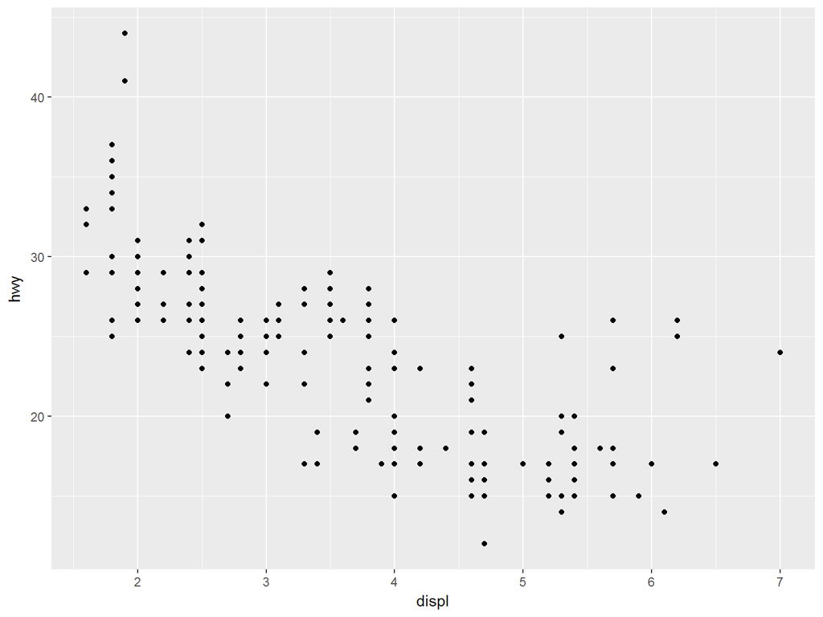

```r
ggplot(data = mpg) +
  geom_point(mapping = aes(x = displ, y = hwy))
```

- As engine size increases, fuel efficiency decreases, roughly.

# Exercises

- Make a scatterplot of `hwy` vs `cyl`.
- What about a scatterplot of `class` vs `drv`?

# Hwy vs cyl

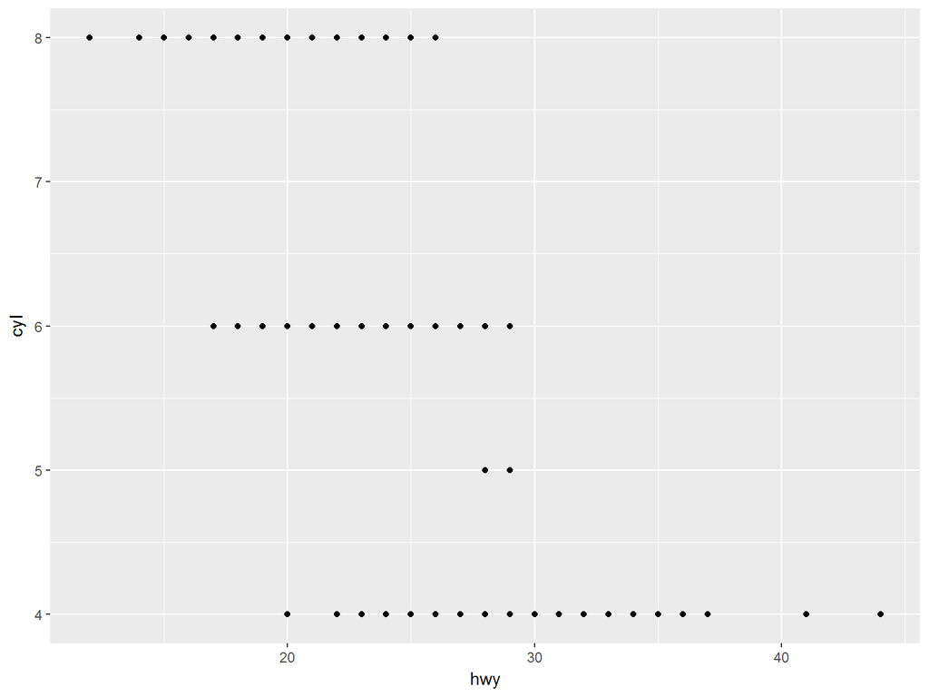

```r
ggplot(data = mpg) +
  geom_point(mapping = aes(x = hwy, y = cyl))
```

# Class vs drv

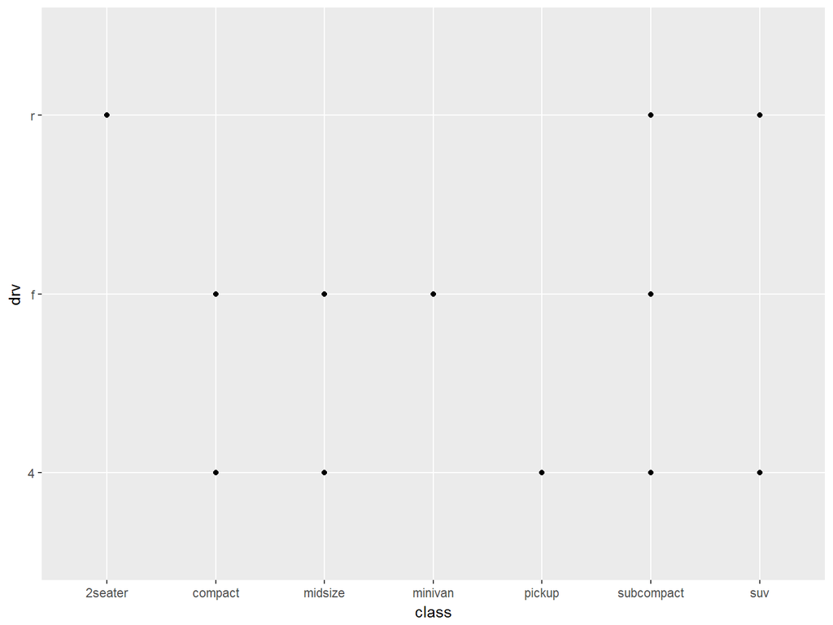

```r
ggplot(data = mpg) +
  geom_point(mapping = aes(x = class, y = drv))
```

What’s going on here? Is this useful? How might we make it more useful?

# Additional aesthetics

What about those outliers? Use the `color` aesthetic.

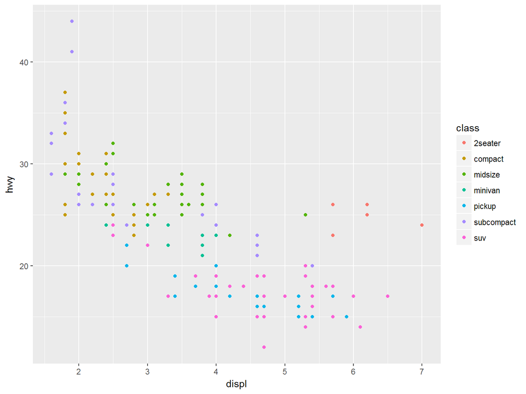

```r
ggplot(data = mpg) +
  geom_point(mapping = aes(x = displ, y = hwy, color = class))
```

# ‘Unmapped’ aesthetics

What’s happening here?

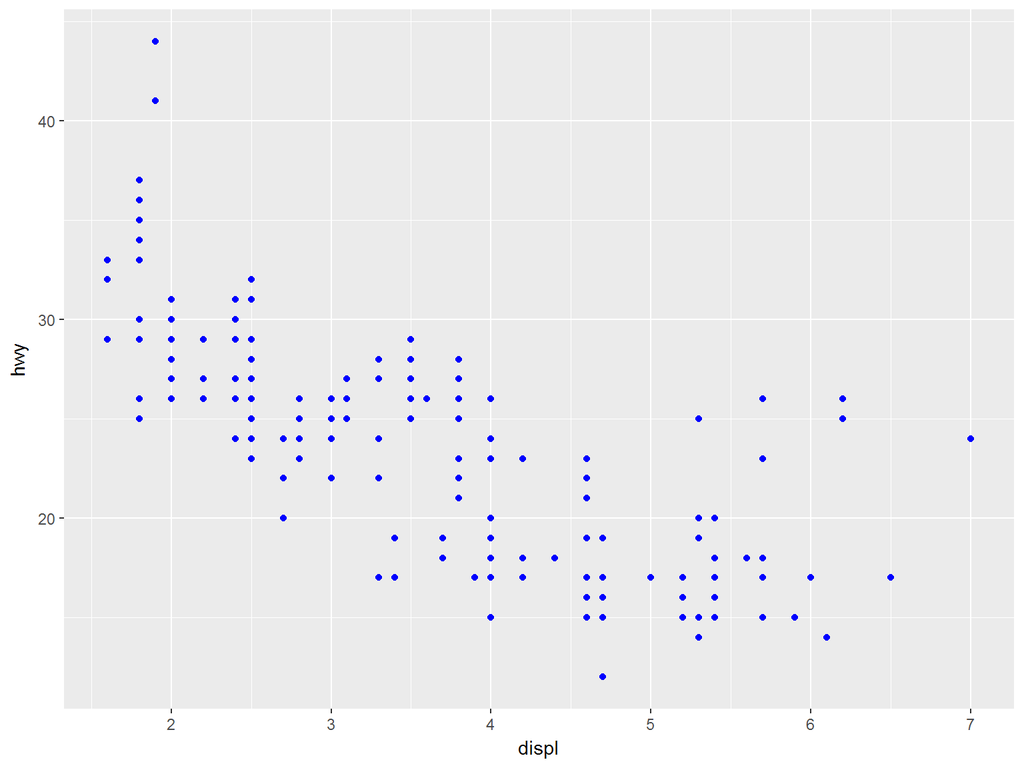

```r
ggplot(data = mpg) +
  geom_point(mapping = aes(x = displ, y = hwy), color = "blue")
```

# What’s gone wrong?

What’s happened here? What colour are the points? Why?

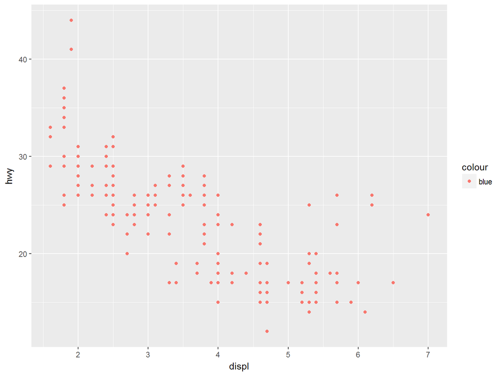

```r
ggplot(data = mpg) +
  geom_point(mapping = aes(x = displ, y = hwy, color = "blue"))
```

# Exercises

- `mpg` variable types: which are categorical, which are continuous?
- `?mpg`
- Map a continuous variable to colour, size, and shape: how are these aesthetics different for categorical vs continuous?
- What happens if you map an aesthetic to something other than a variable name, like `aes(color = displ < 5)`?

# Facets: One Variable

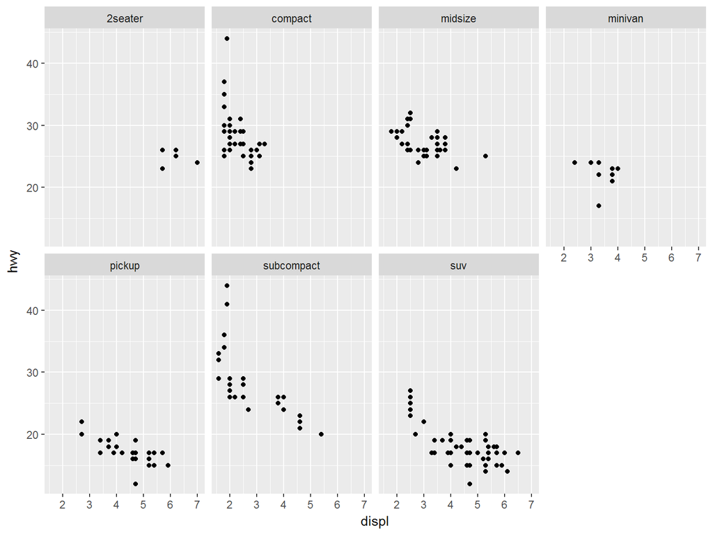

```r
ggplot(data = mpg) +
  geom_point(mapping = aes(x = displ, y = hwy)) +
  facet_wrap(~ class, nrow = 2)
```

# Facets: Two Variables

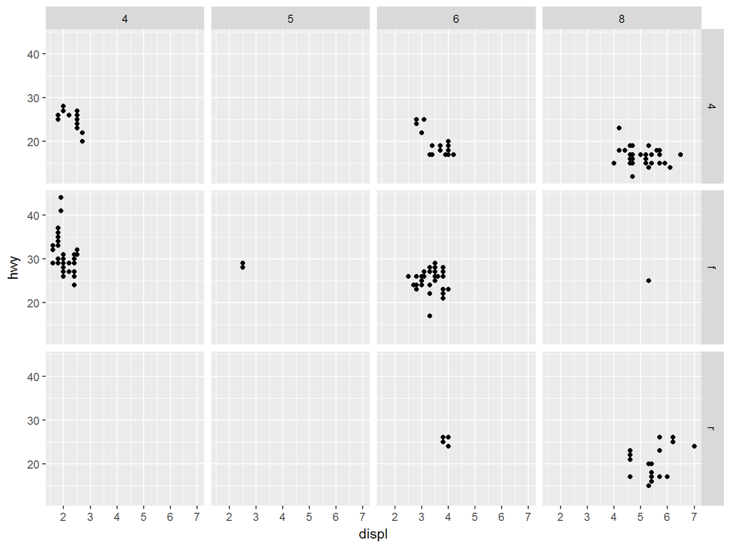

```r
ggplot(data = mpg) +
  geom_point(mapping = aes(x = displ, y = hwy)) +
  facet_grid(drv ~ cyl)
```

# Other “geoms” (geometries)

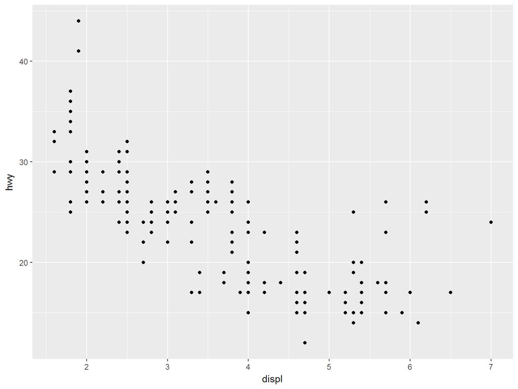

```r
ggplot(data = mpg) +
  geom_point(mapping = aes(x = displ, y = hwy))
```

# Smooth

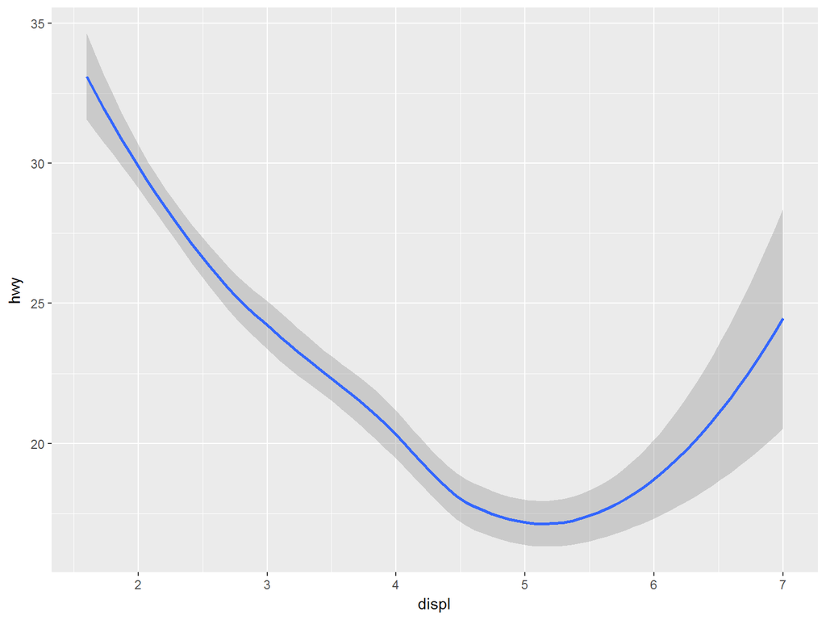

```r
ggplot(data = mpg) +
  geom_smooth(mapping = aes(x = displ, y = hwy))
```

# Smooth aesthetics

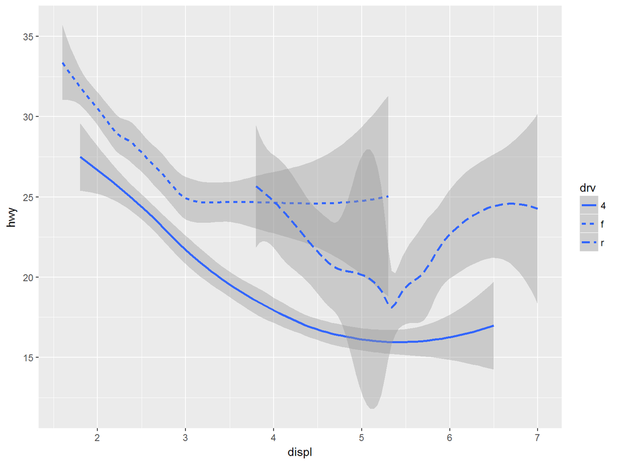

```r
ggplot(data = mpg) +
  geom_smooth(mapping = aes(x = displ, y = hwy, linetype = drv))
```

# Which aesthetics to geoms have?

`?geom_smooth`

# Clearer?

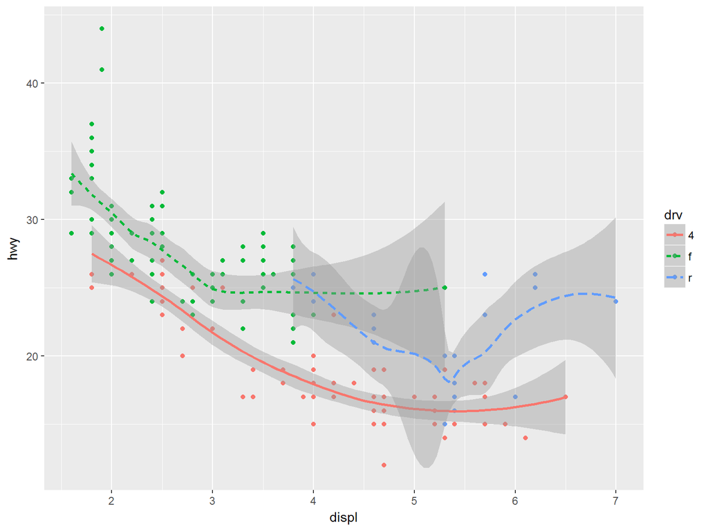

```r
ggplot(data = mpg) +
  geom_point(mapping = aes(x = displ, y = hwy, color = drv)) +
  geom_smooth(mapping = aes(x = displ, y = hwy, color = drv, linetype = drv))
```

# Reducing Duplication

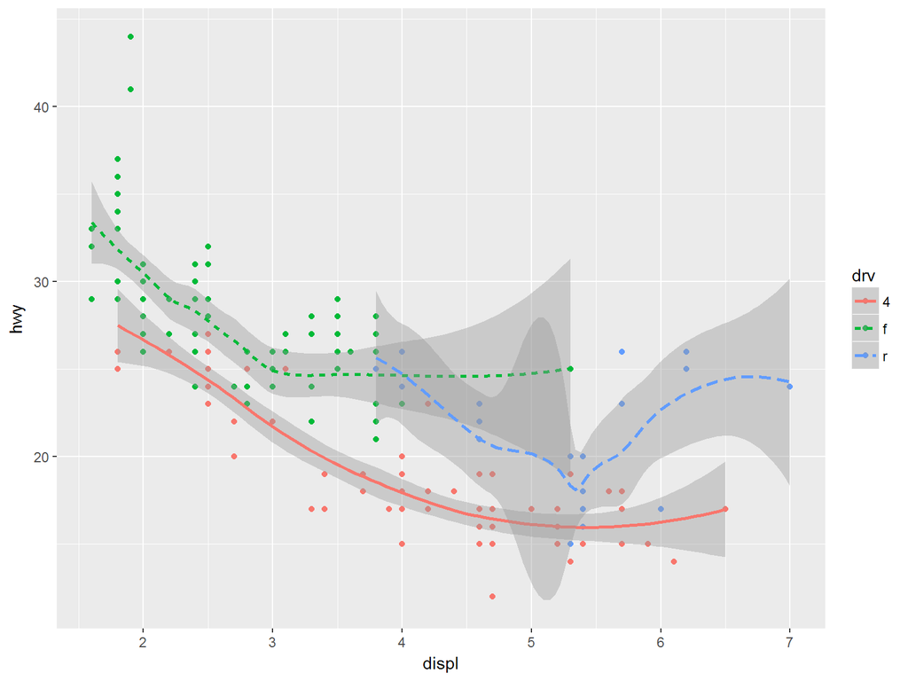

```r
ggplot(data = mpg, mapping = aes(x = displ, y = hwy, color = drv)) +
  geom_point() +
  geom_smooth(mapping = aes(linetype = drv))
```

# Exercise: Recreate:

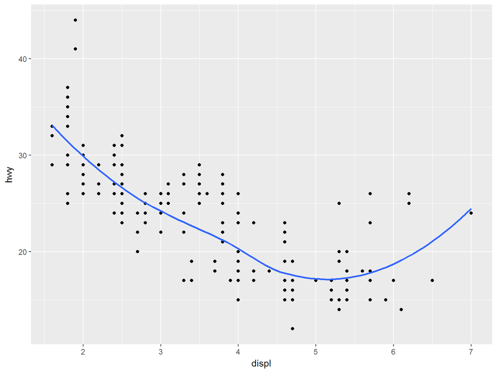

# Exercise: Recreate:

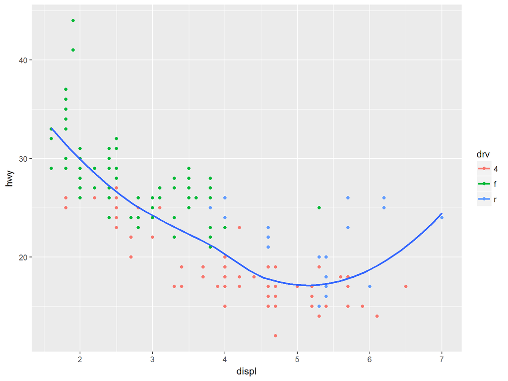

# Exercise: Recreate:

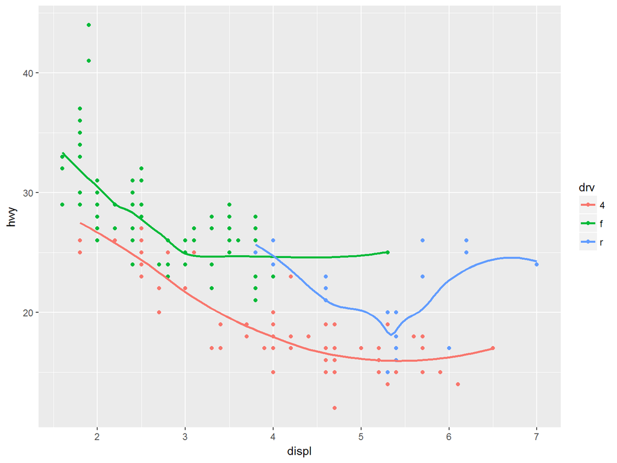

# One last visualization

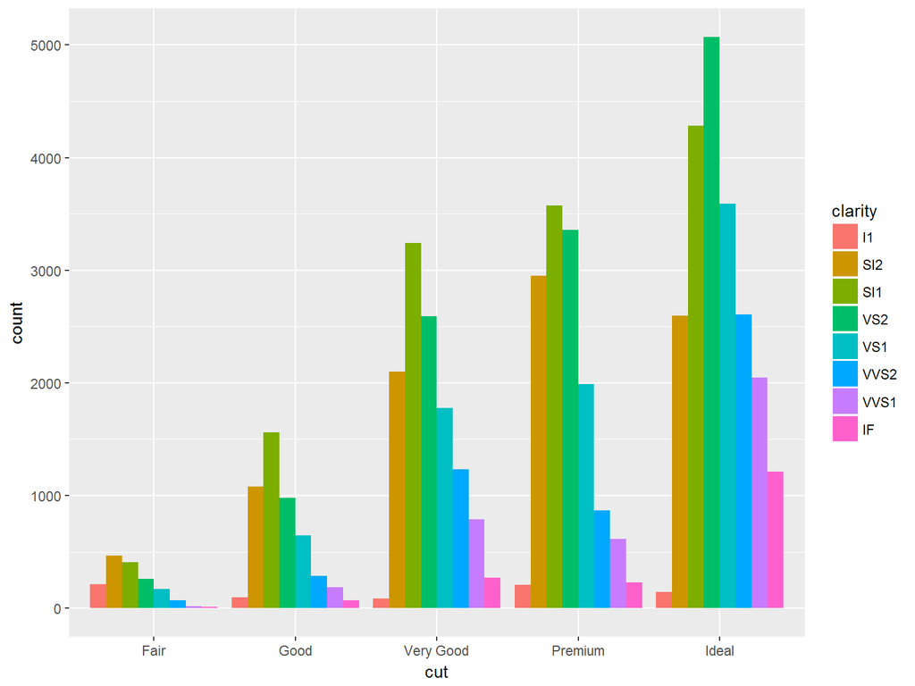

```r
ggplot(data = diamonds) +
  geom_bar(mapping = aes(x = cut, fill = clarity), position = "dodge")
```

# Coding basics

# R as a calculator

```r
1 / 200 * 30
```

```
## [1] 0.15
```

```r
(59 + 73 + 2) / 3
```

```
## [1] 44.66667
```

```r
sin(pi / 2)
```

```
## [1] 1
```

# Assignments

```r
x <- 3 * 4
```

# Calling functions

R functions, in general:

```
function_name(arg1 = val1, arg2 = val2, ...)
```

An example function, `seq`:

```r
seq(1, 10)
```

```
##  [1]  1  2  3  4  5  6  7  8  9 10
```

# Transformation

# dplyr basics

- Pick observations by their values (`filter()`).
- Reorder the rows (`arrange()`).
- Pick variables by their names (`select()`).
- Create new variables with functions of existing variables (`mutate()`).
- Collapse many values down to a single summary (`summarise()`).
- Can be used in conjunction with `group_by()`

# NYC Flights

```r
# install.packages('nycflights13') # install this package if you don't have it already
library(nycflights13)
```

# NYC Flights

```r
flights
```

```
## # A tibble: 336,776 × 19
##     year month   day dep_time sched_dep_time dep_delay arr_time
##    <int> <int> <int>    <int>          <int>     <dbl>    <int>
## 1   2013     1     1      517            515         2      830
## 2   2013     1     1      533            529         4      850
## 3   2013     1     1      542            540         2      923
## 4   2013     1     1      544            545        -1     1004
## 5   2013     1     1      554            600        -6      812
## 6   2013     1     1      554            558        -4      740
## 7   2013     1     1      555            600        -5      913
## 8   2013     1     1      557            600        -3      709
## 9   2013     1     1      557            600        -3      838
## 10  2013     1     1      558            600        -2      753
## # ... with 336,766 more rows, and 12 more variables: sched_arr_time <int>,
## #   arr_delay <dbl>, carrier <chr>, flight <int>, tailnum <chr>,
## #   origin <chr>, dest <chr>, air_time <dbl>, distance <dbl>, hour <dbl>,
## #   minute <dbl>, time_hour <dttm>
```

What do we see here?

# Filter rows

```r
filter(flights, month == 1, day == 1)
```

```
## # A tibble: 842 × 19
##     year month   day dep_time sched_dep_time dep_delay arr_time
##    <int> <int> <int>    <int>          <int>     <dbl>    <int>
## 1   2013     1     1      517            515         2      830
## 2   2013     1     1      533            529         4      850
## 3   2013     1     1      542            540         2      923
## 4   2013     1     1      544            545        -1     1004
## 5   2013     1     1      554            600        -6      812
## 6   2013     1     1      554            558        -4      740
## 7   2013     1     1      555            600        -5      913
## 8   2013     1     1      557            600        -3      709
## 9   2013     1     1      557            600        -3      838
## 10  2013     1     1      558            600        -2      753
## # ... with 832 more rows, and 12 more variables: sched_arr_time <int>,
## #   arr_delay <dbl>, carrier <chr>, flight <int>, tailnum <chr>,
## #   origin <chr>, dest <chr>, air_time <dbl>, distance <dbl>, hour <dbl>,
## #   minute <dbl>, time_hour <dttm>
```

# Comparison operators

```
>
>=
<
<=
!=
==
```

What will this do?

```
filter(flights, month = 1)
```

# Logical operators

*How can we find flights that departed in November or December?*

# Missing data

```r
NA > 5
```

```
## [1] NA
```

```r
10 == NA
```

```
## [1] NA
```

```r
NA + 10
```

```
## [1] NA
```

What about this?

```
NA / 2
```

# Filtering and NAs

```r
x <- NA
is.na(x)
```

```
## [1] TRUE
```

`filter()` only includes rows where the condition is `TRUE`; it excludes both `FALSE` and `NA` values. If you want to preserve missing values, ask for them explicitly:

```r
df <- tibble(x = c(1, NA, 3))
filter(df, x > 1)
```

```
## # A tibble: 1 × 1
##       x
##   <dbl>
## 1     3
```

```r
filter(df, is.na(x) | x > 1)
```

```
## # A tibble: 2 × 1
##       x
##   <dbl>
## 1    NA
## 2     3
```

# Exercises

- Find all flights that
  - Had an arrival delay of two or more hours
  - Flew to Houston (IAH or HOU)
  - Were operated by United, American, or Delta
  - Departed in summer (July, August, and September)
  - Arrived more than two hours late, but didn’t leave late
  - Were delayed by at least an hour, but made up over 30 minutes in flight
  - Departed between midnight and 6am (inclusive)
- How many flights have a missing `dep_time`? What other variables are missing? What might these rows represent?

# Arranging rows

```r
arrange(flights, year, month, day)
```

```
## # A tibble: 336,776 × 19
##     year month   day dep_time sched_dep_time dep_delay arr_time
##    <int> <int> <int>    <int>          <int>     <dbl>    <int>
## 1   2013     1     1      517            515         2      830
## 2   2013     1     1      533            529         4      850
## 3   2013     1     1      542            540         2      923
## 4   2013     1     1      544            545        -1     1004
## 5   2013     1     1      554            600        -6      812
## 6   2013     1     1      554            558        -4      740
## 7   2013     1     1      555            600        -5      913
## 8   2013     1     1      557            600        -3      709
## 9   2013     1     1      557            600        -3      838
## 10  2013     1     1      558            600        -2      753
## # ... with 336,766 more rows, and 12 more variables: sched_arr_time <int>,
## #   arr_delay <dbl>, carrier <chr>, flight <int>, tailnum <chr>,
## #   origin <chr>, dest <chr>, air_time <dbl>, distance <dbl>, hour <dbl>,
## #   minute <dbl>, time_hour <dttm>
```

```r
arrange(flights, desc(arr_delay))
```

```
## # A tibble: 336,776 × 19
##     year month   day dep_time sched_dep_time dep_delay arr_time
##    <int> <int> <int>    <int>          <int>     <dbl>    <int>
## 1   2013     1     9      641            900      1301     1242
## 2   2013     6    15     1432           1935      1137     1607
## 3   2013     1    10     1121           1635      1126     1239
## 4   2013     9    20     1139           1845      1014     1457
## 5   2013     7    22      845           1600      1005     1044
## 6   2013     4    10     1100           1900       960     1342
## 7   2013     3    17     2321            810       911      135
## 8   2013     7    22     2257            759       898      121
## 9   2013    12     5      756           1700       896     1058
## 10  2013     5     3     1133           2055       878     1250
## # ... with 336,766 more rows, and 12 more variables: sched_arr_time <int>,
## #   arr_delay <dbl>, carrier <chr>, flight <int>, tailnum <chr>,
## #   origin <chr>, dest <chr>, air_time <dbl>, distance <dbl>, hour <dbl>,
## #   minute <dbl>, time_hour <dttm>
```

# Selecting columns

```r
select(flights, year, month, day)
```

```
## # A tibble: 336,776 × 3
##     year month   day
##    <int> <int> <int>
## 1   2013     1     1
## 2   2013     1     1
## 3   2013     1     1
## 4   2013     1     1
## 5   2013     1     1
## 6   2013     1     1
## 7   2013     1     1
## 8   2013     1     1
## 9   2013     1     1
## 10  2013     1     1
## # ... with 336,766 more rows
```

```r
select(flights, year:day)
```

```
## # A tibble: 336,776 × 3
##     year month   day
##    <int> <int> <int>
## 1   2013     1     1
## 2   2013     1     1
## 3   2013     1     1
## 4   2013     1     1
## 5   2013     1     1
## 6   2013     1     1
## 7   2013     1     1
## 8   2013     1     1
## 9   2013     1     1
## 10  2013     1     1
## # ... with 336,766 more rows
```

# Select helper functions

- There are a number of helper functions you can use within select():
  - `starts_with("abc")`: matches names that begin with “abc”.
  - `ends_with("xyz")`: matches names that end with “xyz”.
  - `contains("ijk")`: matches names that contain “ijk”.
  - `matches("(.)\\1")`: selects variables that match a regular expression.
  - `num_range("x", 1:3)`: matches x1, x2 and x3.
  - `one_of(vector)`: columns whose names are in said vector.

# Add new variables with mutate

```r
flights_sml <- select(flights,
  year:day,
  ends_with("delay"),
  distance,
  air_time
)

mutate(flights_sml,
  gain = arr_delay - dep_delay,
  speed = distance / air_time * 60
)
```

```
## # A tibble: 336,776 × 9
##     year month   day dep_delay arr_delay distance air_time  gain    speed
##    <int> <int> <int>     <dbl>     <dbl>    <dbl>    <dbl> <dbl>    <dbl>
## 1   2013     1     1         2        11     1400      227     9 370.0441
## 2   2013     1     1         4        20     1416      227    16 374.2731
## 3   2013     1     1         2        33     1089      160    31 408.3750
## 4   2013     1     1        -1       -18     1576      183   -17 516.7213
## 5   2013     1     1        -6       -25      762      116   -19 394.1379
## 6   2013     1     1        -4        12      719      150    16 287.6000
## 7   2013     1     1        -5        19     1065      158    24 404.4304
## 8   2013     1     1        -3       -14      229       53   -11 259.2453
## 9   2013     1     1        -3        -8      944      140    -5 404.5714
## 10  2013     1     1        -2         8      733      138    10 318.6957
## # ... with 336,766 more rows
```

# Useful “mutations”

- Arithmetic: `+, -, *, /, ^`
- Modular arithmetic: `%/%` (integer division), `%%` (remainder)
- Logs: `log(), log2(), log10()`
- Offsets: `lead()`, `lag()`
- Cumulative and rolling aggregates: `cumsum()`, `cumprod()`, `cummin()`, `cummax()`, `cummean()`
- Logical comparisons: `<, <=, >, >=, !=, ==`
- Ranking: `min_rank()`, `row_number()`, `dense_rank()`, `percent_rank()`, `cume_dist()`, `ntile()`
- `ifelse()`
- `decode()`

# Dealing with vectors…

```r
c(1,2,3)
```

```
## [1] 1 2 3
```

```r
1:3
```

```
## [1] 1 2 3
```

# Dealing with vectors…

```r
1:3 + 1:9
```

```
## [1]  2  4  6  5  7  9  8 10 12
```

What about…

```
1:3 + 1:10
```

# Dealing with vectors…

```r
1:3 + 1:10
```

```
##  [1]  2  4  6  5  7  9  8 10 12 11
```

What happened?

# Summarising

```r
summarise(flights, delay = mean(dep_delay, na.rm = TRUE))
```

```
## # A tibble: 1 × 1
##      delay
##      <dbl>
## 1 12.63907
```

# Summarising, with groups

```r
by_day <- group_by(flights, year, month, day)
summarise(by_day, delay = mean(dep_delay, na.rm = TRUE))
```

```
## Source: local data frame [365 x 4]
## Groups: year, month [?]
##
##     year month   day     delay
##    <int> <int> <int>     <dbl>
## 1   2013     1     1 11.548926
## 2   2013     1     2 13.858824
## 3   2013     1     3 10.987832
## 4   2013     1     4  8.951595
## 5   2013     1     5  5.732218
## 6   2013     1     6  7.148014
## 7   2013     1     7  5.417204
## 8   2013     1     8  2.553073
## 9   2013     1     9  2.276477
## 10  2013     1    10  2.844995
## # ... with 355 more rows
```

# Combining operations

A new variable for each step gets cumbersome, so `dplyr` provides an operator, the pipe (`%>%`) that combines operations:

```r
flights %>%
  group_by(year, month, day) %>%
  summarise(delay = mean(dep_delay, na.rm = TRUE)) %>%
  head(5)
```

```
## Source: local data frame [5 x 4]
## Groups: year, month [1]
##
##    year month   day     delay
##   <int> <int> <int>     <dbl>
## 1  2013     1     1 11.548926
## 2  2013     1     2 13.858824
## 3  2013     1     3 10.987832
## 4  2013     1     4  8.951595
## 5  2013     1     5  5.732218
```

`x %>% f(y)` turns into `f(x, y)`, and `x %>% f(y) %>% g(z)` turns into `g(f(x, y), z)` etc.

# Missing values

Let’s come back to that `na.rm()` from above:

```r
mean(c(1,2,3))
```

```
## [1] 2
```

What do we expect here?

```
mean(c(1,NA,3))
```

# Missing values

```r
mean(c(1,NA,3))
```

```
## [1] NA
```

```r
mean(c(1,NA,3), na.rm = TRUE)
```

```
## [1] 2
```

# Counts

```r
flights %>%
  group_by(month) %>%
  summarise(n = n())
```

```
## # A tibble: 12 × 2
##    month     n
##    <int> <int>
## 1      1 27004
## 2      2 24951
## 3      3 28834
## 4      4 28330
## 5      5 28796
## 6      6 28243
## 7      7 29425
## 8      8 29327
## 9      9 27574
## 10    10 28889
## 11    11 27268
## 12    12 28135
```

# Counts, shorthand:

```r
flights %>%
  count(month)
```

```
## # A tibble: 12 × 2
##    month     n
##    <int> <int>
## 1      1 27004
## 2      2 24951
## 3      3 28834
## 4      4 28330
## 5      5 28796
## 6      6 28243
## 7      7 29425
## 8      8 29327
## 9      9 27574
## 10    10 28889
## 11    11 27268
## 12    12 28135
```

# Useful summarising functions:

- `mean(x)`, `median(x)`
- `sd(x)`, `IQR(x)` (interquartile range), `mad(x)` (median absolute deviation)
- `min(x)`, `max(x)`, `quantile(x, 0.25)`
- `first(x)`, `nth(x, 2)`, `last(x)`
- `n(x)`, `n_distinct(x)`
- Counts and proportions of logical values: `sum(x > 10)`, `mean(y == 0)`
  - `TRUE` is converted to `1` and `FALSE` to `0`

# Logical sums

Number of flights before 5:00am:

```r
flights %>%
  filter(!is.na(dep_delay), !is.na(arr_delay)) %>%
  group_by(year, month, day) %>%
  summarise(n_early = sum(dep_time < 500))
```

```
## Source: local data frame [365 x 4]
## Groups: year, month [?]
##
##     year month   day n_early
##    <int> <int> <int>   <int>
## 1   2013     1     1       0
## 2   2013     1     2       3
## 3   2013     1     3       4
## 4   2013     1     4       3
## 5   2013     1     5       3
## 6   2013     1     6       2
## 7   2013     1     7       2
## 8   2013     1     8       1
## 9   2013     1     9       3
## 10  2013     1    10       3
## # ... with 355 more rows
```

# Grouped mutates

```r
flights %>%
  filter(!is.na(arr_delay)) %>%
  group_by(year, month) %>%
  summarise(n_delayed = sum(arr_delay > 30)) %>%
  group_by(year) %>%
  mutate(
    n_delayed_year = sum(n_delayed),
    pct = (n_delayed / n_delayed_year) * 100
    )
```

```
## Source: local data frame [12 x 5]
## Groups: year [1]
##
##     year month n_delayed n_delayed_year       pct
##    <int> <int>     <int>          <int>     <dbl>
## 1   2013     1      3740          51499  7.262277
## 2   2013     2      3371          51499  6.545758
## 3   2013     3      4279          51499  8.308899
## 4   2013     4      5199          51499 10.095342
## 5   2013     5      4190          51499  8.136080
## 6   2013     6      6200          51499 12.039069
## 7   2013     7      6606          51499 12.827434
## 8   2013     8      4542          51499  8.819589
## 9   2013     9      2318          51499  4.501058
## 10  2013    10      2718          51499  5.277772
## 11  2013    11      2630          51499  5.106895
## 12  2013    12      5706          51499 11.079827
```

# Some statistical tests

# Loading Data

- From a text file (CSV, tab delimited, etc) file
  - The `readr` package is likely best.
- From an SPSS file (or Stata or SAS)
  - I recommend `haven` for this.
- Directly from a database
  - Depends on the database. Best to use an abstraction layer like `DBI` or `RODBC`/`RJDBC`.

# Let’s dig in

1. Create an RStudio Project
2. [Google: “machine learning student performance”](https://www.google.ca/search?q=machine+learning+student+performance)
3. [UCI Machine Learning Repository](https://archive.ics.uci.edu/ml/datasets/Student+Performance)
4. [Download the data](https://archive.ics.uci.edu/ml/machine-learning-databases/00320/student.zip)
5. Unzip student.zip into the directory where you created the RStudio project
   - You’ll have two files: student-mat.csv (math grades) and student-por.csv (Portuguese grades)

# Loading

```r
students <- read_delim("student-mat.csv", delim=";")
```

# Basic statistical functions

- t-test
- Correlation
- Chi-square
- Basic linear models

# t-test

Is there difference in the mean first period grade for men and women significant?

```r
t.test(G1 ~ sex, data = students) # using formula notation
```

```
##
##  Welch Two Sample t-test
##
## data:  G1 by sex
## t = -1.8237, df = 383.79, p-value = 0.06898
## alternative hypothesis: true difference in means is not equal to 0
## 95 percent confidence interval:
##  -1.26715575  0.04764732
## sample estimates:
## mean in group F mean in group M
##        10.62019        11.22995
```

Likely not: *p* > 0.05.

# Correlation

Are first period grades and second period grades correlated?

```r
cor(students$G1, students$G2) # passing vectors
```

```
## [1] 0.8521181
```

By default, `cor()` returns Pearson’s *r*. These grades appear highly correlated.

# Correlation

R can also run this as a statistical test of correlation:

```r
cor.test(students$G1, students$G2)
```

```
##
##  Pearson's product-moment correlation
##
## data:  students$G1 and students$G2
## t = 32.278, df = 393, p-value < 2.2e-16
## alternative hypothesis: true correlation is not equal to 0
## 95 percent confidence interval:
##  0.8226117 0.8770475
## sample estimates:
##       cor
## 0.8521181
```

*p* < 0.001, narrow confidence interval for *r*, we can feel pretty confident about this correlation.

# Chi-squared test

Does there appear to be a difference between the address (urban vs rural) and family size (3 or fewer members, or more than 3 members)?

```r
table(students$address, students$famsize) # simple crosstab
```

```
##
##     GT3 LE3
##   R  68  20
##   U 213  94
```

```r
chisq.test(table(students$address, students$famsize)) # pass the table to chisq.test()
```

```
##
##  Pearson's Chi-squared test with Yates' continuity correction
##
## data:  table(students$address, students$famsize)
## X-squared = 1.7081, df = 1, p-value = 0.1912
```

Chi-squared test not significant, *p* > 0.05.

# Chi-squared test

We might also want to examine the residuals, in which case we need to save the results of the test to a variable:

```r
chisq_results <- chisq.test(table(students$address, students$famsize))
```

Simple residuals:

```r
chisq_results$observed - chisq_results$expected
```

```
##
##           GT3       LE3
##   R  5.397468 -5.397468
##   U -5.397468  5.397468
```

# Chi-squared test

Pearson residuals (SPSS calls these “standardized residuals”):

```r
chisq_results$residuals
```

```
##
##            GT3        LE3
##   R  0.6821724 -1.0710134
##   U -0.3652299  0.5734123
```

Standardized residuals (SPSS calls these “adjusted standardized residuals”):

```r
chisq_results$stdres
```

```
##
##           GT3       LE3
##   R  1.440355 -1.440355
##   U -1.440355  1.440355
```

# Simple linear models

Second period grade predicted by first period grade:

```r
lm(G2 ~ G1, data = students)
```

```
##
## Call:
## lm(formula = G2 ~ G1, data = students)
##
## Coefficients:
## (Intercept)           G1
##      0.1796       0.9657
```

The plain output of `lm()` isn’t terribly useful, best to save to a variable and run `summary()`.

# Simple linear models

```r
lm_results <- lm(G2 ~ G1, data = students)
summary(lm_results)
```

```
##
## Call:
## lm(formula = G2 ~ G1, data = students)
##
## Residuals:
##      Min       1Q   Median       3Q      Max
## -11.7676  -0.8363   0.1637   1.1637   4.1981
##
## Coefficients:
##             Estimate Std. Error t value Pr(>|t|)
## (Intercept)  0.17957    0.34110   0.526    0.599
## G1           0.96567    0.02992  32.278   <2e-16 ***
## ---
## Signif. codes:  0 '***' 0.001 '**' 0.01 '*' 0.05 '.' 0.1 ' ' 1
##
## Residual standard error: 1.971 on 393 degrees of freedom
## Multiple R-squared:  0.7261, Adjusted R-squared:  0.7254
## F-statistic:  1042 on 1 and 393 DF,  p-value: < 2.2e-16
```

Now we see residual distribution, t-tests on the coefficients, R<sup>2</sup>, and the results of the F-test.

We can see that this model explains a large portion of the variance (Adjusted R<sup>2</sup>: 0.7254) and that G1 and G2 are strongly colinear–unsurprising given the results of the earlier correlation test.

# The `broom` package

In R, the output of the various modelling an dtesting functions is usually in the form of a list. This list is then printed directly to the console or can be passed to a function like `summary()`, as we saw above. However, for programmatic, rather than interactive, uses, it can be awkward to deal with these lists. Enter `broom`, a package designed to convert model outputs into tidy data frames.

```r
library(broom)
```

`broom` has three main functions:

- `tidy()`: coefficient level output
- `glance()`: model level output (e.g., R<sup>2</sup> in a linear model)
- `augment()`: data level output (e.g., in a linear model, actuals and residuals)

# `tidy()`

```r
lm_results <- lm(G2 ~ G1, data = students)

tidy(lm_results)
```

```
##          term  estimate  std.error  statistic       p.value
## 1 (Intercept) 0.1795666 0.34110139  0.5264317  5.988853e-01
## 2          G1 0.9656698 0.02991744 32.2778169 1.441347e-112
```

Result: a data frame of the coefficients in the model.

# `glance()`

```r
glance(lm_results)
```

```
##   r.squared adj.r.squared    sigma statistic       p.value df    logLik
## 1 0.7261052     0.7254083 1.971085  1041.857 1.441347e-112  2 -827.5189
##        AIC      BIC deviance df.residual
## 1 1661.038 1672.974 1526.874         393
```

Result: a data frame with columns for “model level” data, like R<sup>2</sup>, the result of the F-test (`statistic` and `p.value`), etc.

# `augment()`

```r
head(augment(lm_results), 10) # just the first 10 rows
```

```
##    G2 G1   .fitted   .se.fit       .resid        .hat   .sigma
## 1   6  5  5.007916 0.2026977  0.992084377 0.010575160 1.972954
## 2   5  5  5.007916 0.2026977 -0.007915623 0.010575160 1.973597
## 3   8  7  6.939255 0.1533349  1.060744764 0.006051614 1.972866
## 4  14 15 14.664614 0.1575334 -0.664613691 0.006387555 1.973310
## 5  10  6  5.973585 0.1772115  4.026414571 0.008083010 1.963006
## 6  15 15 14.664614 0.1575334  0.335386309 0.006387555 1.973524
## 7  12 12 11.767604 0.1044104  0.232395730 0.002805928 1.973562
## 8   5  6  5.973585 0.1772115 -0.973585429 0.008083010 1.972980
## 9  18 16 15.630283 0.1817564  2.369716503 0.008502937 1.969934
## 10 15 14 13.698944 0.1356033  1.301056116 0.004732926 1.972498
##         .cooksd   .std.resid
## 1  1.368289e-03  0.506001579
## 2  8.710655e-08 -0.004037275
## 3  8.870021e-04  0.539788523
## 4  3.677888e-04 -0.338263733
## 5  1.714031e-02  2.051046423
## 6  9.365924e-05  0.170699200
## 7  1.961249e-05  0.118068206
## 8  1.002144e-03 -0.495942203
## 9  6.250838e-03  1.207383795
## 10 1.040883e-03  0.661638664
```

Result: a data frame with the “input” values (G2 and G1) and then the results of fitting the model.

# `broom` in action

Where `broom` really shines is as part of a `dplyr` workflow, like we looked at above.

Run a series of linear models predicting G2 from G1 by sex and school:

```r
students %>%
  group_by(sex, school) %>%
  do(tidy(lm(G2 ~ G1, data = .)))
```

```
## Source: local data frame [8 x 7]
## Groups: sex, school [4]
##
##     sex school        term   estimate  std.error  statistic      p.value
##   <chr>  <chr>       <chr>      <dbl>      <dbl>      <dbl>        <dbl>
## 1     F     GP (Intercept)  0.3448663 0.54003117  0.6386044 5.238875e-01
## 2     F     GP          G1  0.9503561 0.04892940 19.4230095 3.873890e-46
## 3     F     MS (Intercept)  0.1553853 0.60802845  0.2555560 8.005653e-01
## 4     F     MS          G1  0.9308255 0.05267525 17.6710229 7.053803e-15
## 5     M     GP (Intercept)  0.1236139 0.54563997  0.2265485 8.210570e-01
## 6     M     GP          G1  0.9774071 0.04604570 21.2268908 6.516662e-49
## 7     M     MS (Intercept) -0.6542587 1.03102356 -0.6345720 5.332748e-01
## 8     M     MS          G1  1.0309148 0.09616335 10.7204541 1.696643e-09
```

# Additional Resources

# Online Resources

Start here:

- http://r4ds.had.co.nz/
- http://stat545.com/

Additional:

- http://adv-r.had.co.nz/
- http://r-pkgs.had.co.nz/
- http://swcarpentry.github.io/r-novice-inflammation/

For help/community:

- http://stackoverflow.com/questions/tagged/r
- https://twitter.com/search?q=%23rstats

# Print Books

- https://us.sagepub.com/en-us/nam/discovering-statistics-using-r/book236067%20
- https://us.sagepub.com/en-us/nam/an-r-companion-to-applied-regression/book233899
- http://shop.oreilly.com/product/0636920028574.do

# References

- Wickham, Hadley (2014). https://www.jstatsoft.org/article/view/v059i10